# Inferencia, correlación y regresión simple

Ayudantía 06 · FAGOB 2026

Cristóbal Mejías · Facultad de Gobierno

Métodos Cuantitativos para la Administración Pública

mayo de 2026

## ¿Qué veremos hoy?

1. Inferencia estadística e intervalos de confianza
2. Correlación de Pearson
3. Regresión lineal simple
4. Ejercicios aplicados con ISSP Chile 2009

[Repositorio de ayudantías](https://github.com/Cristobal-Mejias-G/metodos-cuantitativos-fagob)

## Paquetes y datos

```r
pacman::p_load(
  tidyverse,     # manipulación de datos y gráficos (dplyr, ggplot2)
  sjmisc,        # descriptivos rápidos (descr, frq)
  parameters,    # resultados de tests y modelos como tabla legible
  gginference,   # visualización de pruebas de hipótesis
  modelsummary   # tablas de regresión
)
```

```r
# Base ISSP 2009 Chile (la misma de la ayudantía 4)
load(url("https://github.com/Cristobal-Mejias-G/metodos-cuantitativos-fagob/raw/main/datos/issp_2009_chile.RData"))
```

```r
# sex viene codificada como 1 y 2: le ponemos nombres a las categorías
issp <- issp |>
  mutate(sex = factor(sex, levels = c("1", "2"), labels = c("Hombre", "Mujer")))
```

# Parte 1: Inferencia estadística

## ¿Por qué inferencia?

### Trabajamos con muestras, no con poblaciones completas.

La inferencia estadística nos permite responder:

- ¿Qué tan probable es que el valor observado en la muestra (estadístico) refleje el valor real en la población (parámetro)?
- ¿Cuál es el rango plausible para ese valor poblacional?
- ¿La diferencia que veo entre dos grupos existe en la población o es producto del azar?

## Intervalo de confianza (IC)

Un IC al 95% nos dice: si repitiéramos el muestreo 100 veces, en 95 de ellas los intervalos construidos contendrían el parámetro poblacional verdadero.

### Fórmula

$$IC = \bar{x} \pm Z \cdot \frac{s}{\sqrt{n}}$$

## IC paso a paso: cada término de la fórmula

```r
ic_edad <- issp |>
  summarise(
    media     = mean(age, na.rm = TRUE),     # x barra
    de        = sd(age, na.rm = TRUE),       # s
    n         = sum(!is.na(age)),            # n
    error_est = de / sqrt(n),                # s / raíz de n
    li        = media - 1.96 * error_est,    # límite inferior
    ls        = media + 1.96 * error_est     # límite superior
  )

ic_edad
```

```
# A tibble: 1 × 6
  media    de     n error_est    li    ls
  <dbl> <dbl> <int>     <dbl> <dbl> <dbl>
1  46.6  17.6  1505     0.455  45.7  47.5
```

## IC con una función

`t.test()` calcula el mismo intervalo (usa la distribución *t* en vez de *Z*, por eso la diferencia es mínima):

```r
t.test(issp$age, conf.level = 0.95)$conf.int
```

```
[1] 45.66977 47.45315
attr(,"conf.level")
[1] 0.95
```

Interpretación: con un 95% de confianza, la edad promedio de la población chilena se encuentra entre 45.67 y 47.45 años.

## Test t: diferencia de medias

### ¿Existen diferencias en el estatus social subjetivo (`topbot`) entre hombres y mujeres?

H0: no hay diferencias

$$H_0: \mu_1 - \mu_2 = 0$$

H1: hay diferencias

$$H_a: \mu_1 - \mu_2 \neq 0$$

```r
t_estatus <- t.test(topbot ~ sex,
                    data        = issp,
                    alternative = "two.sided",
                    conf.level  = 0.95)
t_estatus
```

```
    Welch Two Sample t-test

data:  topbot by sex
t = 0.28718, df = 1322.9, p-value = 0.774
alternative hypothesis: true difference in means between group Hombre and group Mujer is not equal to 0
95 percent confidence interval:
 -0.1465582  0.1968265
sample estimates:
mean in group Hombre  mean in group Mujer
            4.040128             4.014994
```

## Test t: resultado como tabla

`parameters::model_parameters()` ordena el resultado de cualquier test en una tabla con nombres claros:

```r
parameters::model_parameters(t_estatus) |>
  print_md()
```

Welch Two Sample t-test

| Parameter | Group | sex = Hombre | sex = Mujer | Difference | 95% CI | t(1322.86) | p |
| --- | --- | --- | --- | --- | --- | --- | --- |
| topbot | sex | 4.04 | 4.01 | 0.03 | (-0.15, 0.20) | 0.29 | 0.774 |

Alternative hypothesis: true difference in means between group Hombre and group Mujer is not equal to 0

## Test t: visualización

```r
# ggttest() necesita el test escrito como base$variable
gginference::ggttest(t.test(issp$topbot ~ issp$sex))
```

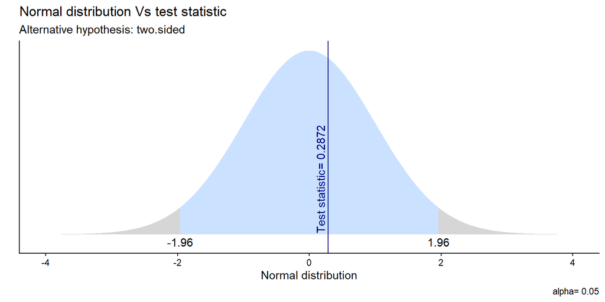

El área sombreada corresponde a la zona de rechazo de H₀ (α/2 en cada cola).

# Parte 2: Correlación de Pearson

## Correlación de Pearson

La correlación de Pearson (*r*) mide la fuerza y dirección de la asociación **lineal** entre dos variables continuas.

$$r = \frac{\sum (x_i - \bar{x})(y_i - \bar{y})}{(n-1) \cdot s_x \cdot s_y}$$

- Va de −1 a 1
- El signo indica la dirección; el valor absoluto, la fuerza

## Primero, mirar los datos

### ¿Se relacionan los años de educación (`educyrs`) con el decil de ingreso (`income`)?

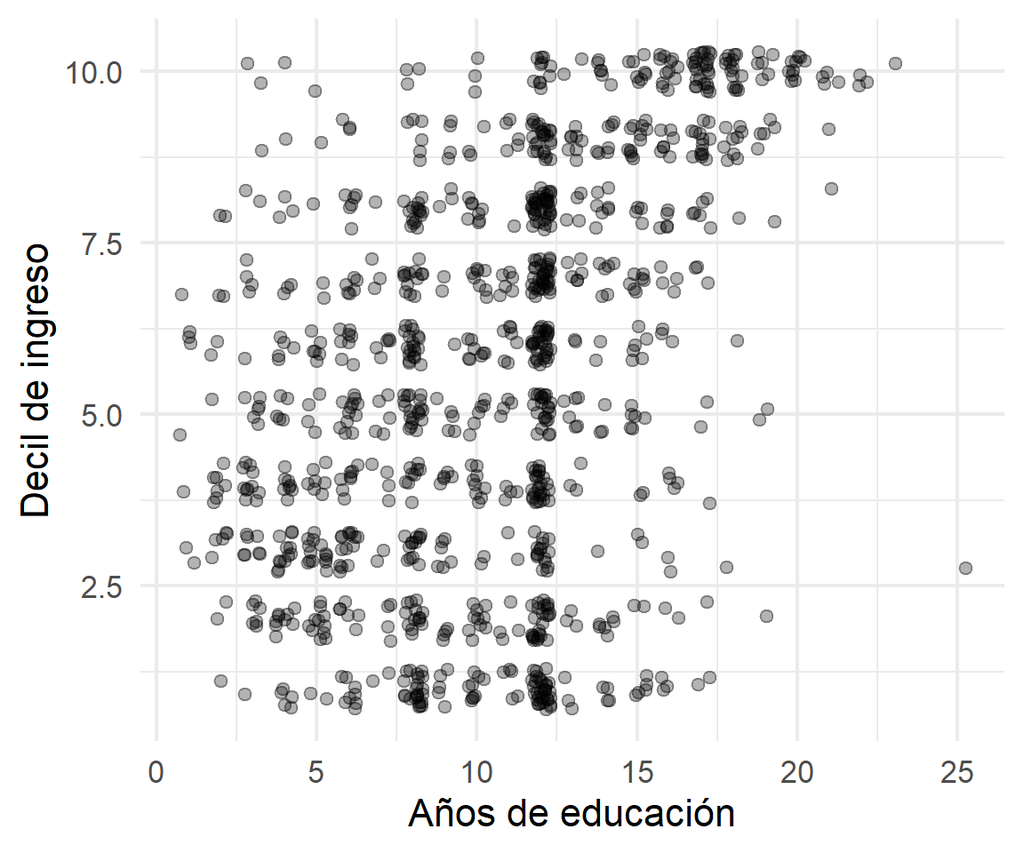

```r
ggplot(issp, aes(x = educyrs, y = income)) +
  geom_jitter(alpha = 0.3,
              width = 0.3,
              height = 0.3) +
  labs(x = "Años de educación",
       y = "Decil de ingreso")
```

`geom_jitter()` mueve levemente cada punto para que no se superpongan los casos con valores iguales.

## Test de correlación

```r
# H0: r = 0 (no hay relación lineal)
# H1: r != 0 (existe relación lineal)
cor_edu <- cor.test(~ educyrs + income,
                    data   = issp,
                    method = "pearson")

parameters::model_parameters(cor_edu) |>
  print_md()
```

Pearson’s product-moment correlation

| Parameter1 | Parameter2 | r | 95% CI | t(1103) | p |
| --- | --- | --- | --- | --- | --- |
| educyrs | income | 0.43 | (0.38, 0.48) | 15.77 | < .001 |

Alternative hypothesis: true correlation is not equal to 0

# Parte 3: Regresión lineal simple

## Modelo de regresión

La recta de regresión representa los valores predichos de Y para los distintos valores de X:

$$\widehat{Y} = b_{0} + b_{1}X$$

- $\widehat{Y}$: valor estimado/predicho de $Y$
- $b_{0}$: **intercepto** (el valor de Y cuando X es 0)
- $b_{1}$: **pendiente**, cuánto cambia Y por cada unidad que aumenta X

## Estimación en R

La función para estimar regresiones en R es `lm()` (*linear model*):

```r
objeto <- lm(dependiente ~ independiente, data = datos)
```

### Ejemplo: ¿la educación predice el estatus social subjetivo?

```r
reg1 <- lm(topbot ~ educyrs, data = issp)
reg1
```

```
Call:
lm(formula = topbot ~ educyrs, data = issp)

Coefficients:
(Intercept)      educyrs
     2.4469       0.1504
```

## Tabla de regresión

```r
modelsummary(
  list("Estatus subjetivo" = reg1),
  stars    = TRUE,
  gof_map  = c("nobs", "r.squared"),
  coef_rename = c("(Intercept)" = "Intercepto",
                  "educyrs" = "Años de educación")
)
```

|  | Estatus subjetivo |
| --- | --- |
| Intercepto | 2.447*** |
|  | (0.105) |
| Años de educación | 0.150*** |
|  | (0.009) |
| Num.Obs. | 1440 |
| R2 | 0.162 |

+ p < 0.1, * p < 0.05, ** p < 0.01, *** p < 0.001

Por cada año adicional de escolaridad, el estatus social subjetivo aumenta en promedio **0.15 puntos** en la escala de 1 a 10.

El intercepto (2.45) es el estatus predicho para alguien con cero años de educación.

El R² indica que los años de educación explican cerca del **16% de la variabilidad** del estatus social subjetivo.

## La recta de regresión sobre los datos

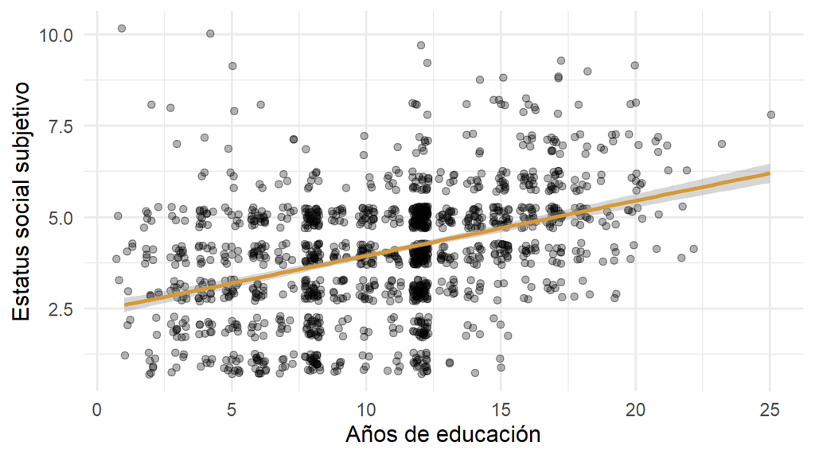

```r
ggplot(issp, aes(x = educyrs, y = topbot)) +
  geom_jitter(alpha = 0.3, width = 0.3, height = 0.3) +
  geom_smooth(method = "lm", se = TRUE, color = "#D49A3B") +
  labs(x = "Años de educación", y = "Estatus social subjetivo")
```

# Parte 4: Ejercicios aplicados

## Datos a utilizar

```r
sjmisc::descr(issp,
              show = c("label", "range", "mean", "sd", "NA.prc", "n")) |>
  knitr::kable(digits = 2)
```

|  | var | label | n | NA.prc | mean | sd | range |
| --- | --- | --- | --- | --- | --- | --- | --- |
| 11 | sex | sex | 1505 | 0.00 | 1.58 | 0.49 | 1 (1-2) |
| 1 | age | Edad | 1505 | 0.00 | 46.56 | 17.64 | 73 (18-91) |
| 6 | educyrs | Nivel educativo | 1451 | 3.59 | 10.76 | 4.41 | 24 (1-25) |
| 7 | income | Decil ingreso | 1146 | 23.85 | 5.49 | 2.87 | 9 (1-10) |
| 12 | topbot | Estatus social subjetivo | 1490 | 1.00 | 4.03 | 1.66 | 9 (1-10) |
| 10 | pref_redis | Preferencia por redistribución | 1477 | 1.86 | 3.83 | 0.88 | 4 (1-5) |
| 9 | perc_ineq | Percepción desigualdad | 1492 | 0.86 | 4.19 | 0.83 | 4 (1-5) |
| 3 | conflict_rp | Conflictos: ricos - pobres | 1438 | 4.45 | 2.61 | 0.87 | 3 (1-4) |
| 5 | conflict_wcmc | Conflictos: clase trabajadora - clase media | 1426 | 5.25 | 2.29 | 0.90 | 3 (1-4) |
| 2 | conflict_mw | Conflictos: directivos - trabajadores | 1427 | 5.18 | 2.71 | 0.83 | 3 (1-4) |
| 4 | conflict_tb | Conflictos: gente de arriba - gente de abajo | 1425 | 5.32 | 2.66 | 0.90 | 3 (1-4) |
| 8 | perc_conflict | Percepción conflictos | 1390 | 7.64 | 6.30 | 2.79 | 12 (0-12) |

## Ejercicio 1: test t

### ¿Existen diferencias en los años de escolaridad (`educyrs`) según sexo (`sex`)?

```r
issp_ej1 <- issp |>
  select(sex, educyrs) |>
  drop_na()

issp_ej1 |>
  group_by(sex) |>
  summarise(n = n(),
            promedio = mean(educyrs),
            de = sd(educyrs)) |>
  knitr::kable(digits = 2)
```

| sex | n | promedio | de |
| --- | --- | --- | --- |
| Hombre | 604 | 11.09 | 4.53 |
| Mujer | 847 | 10.53 | 4.31 |

1. Formula H0 y H1 en función de la pregunta
2. Ejecuta el test t con 95% de confianza
3. Presenta los resultados con `model_parameters()` y visualiza con `ggttest()`
4. Interpreta: ¿es posible rechazar H0?

## Ejercicio 2: correlación

### ¿Qué relación existe entre el decil de ingreso (`income`) y la percepción de conflicto (`perc_conflict`)?

1. Prepara una base con las variables de interés y sin casos perdidos (`drop_na()`)
2. Genera un gráfico de dispersión con `ggplot()`
3. Formula H0 y H1 en función de la pregunta
4. Ejecuta `cor.test()`
5. Presenta los resultados con `model_parameters()`
6. Interpreta: ¿es posible rechazar H0?

## Ejercicio 3: regresión

### ¿En qué medida los años de educación (`educyrs`) predicen el decil de ingreso (`income`)?

1. Prepara una base con ambas variables y sin casos perdidos
2. Genera un gráfico de dispersión con la recta de regresión (`geom_smooth(method = "lm")`)
3. Estima el modelo con `lm()`
4. Presenta los resultados con `modelsummary()`
5. Interpreta intercepto, pendiente y R², con sus niveles de significancia

## Ejercicio 4: regresión 2

### ¿En qué medida el estatus social subjetivo (`topbot`) predice la percepción de conflicto (`perc_conflict`)?

1. Prepara la base con ambas variables
2. Estima el modelo con `lm()`
3. Presenta los resultados con `modelsummary()`
4. Interpreta los coeficientes e indica si el modelo es estadísticamente significativo

## Ejercicio 5: regresión 3

### A partir de los resultados del ejercicio 4:

1. ¿Qué valor de percepción de conflicto predice el modelo para alguien con `topbot = 9`? Calcúlalo usando los coeficientes.
2. ¿Cuál es la relación entre la correlación y el R²?

Pista: usa `cor(base$variable1, base$variable2, use = "complete.obs")`

# Resumen

## Lo que vimos hoy

- **Intervalo de confianza:** rango plausible para el parámetro poblacional, calculado paso a paso y con `t.test()`
- **Test t:** contraste de medias entre dos grupos independientes
- **Correlación de Pearson:** asociación lineal entre dos variables continuas
- **Regresión lineal simple:** coeficientes e interpretación

[Repositorio de ayudantías](https://github.com/Cristobal-Mejias-G/metodos-cuantitativos-fagob)

# Nos vemos en la próxima ayudantía. ¡Gracias por su atención!